# Tugas Kuliah

# Data

```r
library(dplyr)
```

```r
library(forecast)
library(graphics)
library(TTR)
library(TSA)
library(lmtest)
library(readxl)
df <- read.csv("D:\\Mine\\Kuliah Journey\\Semester 5\\MPDW\\mpdw_066\\Pertemuan 3\\Kuliah\\ipm_panel_wide_2010_2021.csv")
head(df)
```

```
##           Provinsi X2010 X2011 X2012 X2013 X2014 X2015 X2016 X2017 X2018 X2019
## 1             ACEH 67.09 67.45 67.81 68.30 68.81 69.45 70.00 70.60 71.19 71.90
## 2   SUMATERA UTARA 67.09 67.34 67.74 68.36 68.87 69.51 70.00 70.57 71.18 71.74
## 3   SUMATERA BARAT 67.25 67.81 68.36 68.91 69.36 69.98 70.73 71.24 71.73 72.39
## 4             RIAU 68.65 68.90 69.15 69.91 70.33 70.84 71.20 71.79 72.44 73.00
## 5            JAMBI 65.39 66.14 66.94 67.76 68.24 68.89 69.62 69.99 70.65 71.26
## 6 SUMATERA SELATAN 64.44 65.12 65.79 66.16 66.75 67.46 68.24 68.86 69.39 70.02
##   X2020 X2021
## 1 71.99 72.18
## 2 71.77 72.00
## 3 72.38 72.65
## 4 72.71 72.94
## 5 71.29 71.63
## 6 70.01 70.24
```

Data yang digunakan adalah data IPM dari provinsi Aceh dengan periode 2010-2021.

```r
library(tidyr)
data_aceh <- df %>% filter(Provinsi == "ACEH") %>%
  pivot_longer (
    cols = starts_with("X"),
    names_to = "Tahun",
    values_to = "Nilai"
  )
data_aceh
```

```
## # A tibble: 12 × 3
##    Provinsi Tahun Nilai
##    <chr>    <chr> <dbl>
##  1 ACEH     X2010  67.1
##  2 ACEH     X2011  67.4
##  3 ACEH     X2012  67.8
##  4 ACEH     X2013  68.3
##  5 ACEH     X2014  68.8
##  6 ACEH     X2015  69.4
##  7 ACEH     X2016  70
##  8 ACEH     X2017  70.6
##  9 ACEH     X2018  71.2
## 10 ACEH     X2019  71.9
## 11 ACEH     X2020  72.0
## 12 ACEH     X2021  72.2
```

# Eksplorasi

```r
str(data_aceh)
```

```
## tibble [12 × 3] (S3: tbl_df/tbl/data.frame)
##  $ Provinsi: chr [1:12] "ACEH" "ACEH" "ACEH" "ACEH" ...
##  $ Tahun   : chr [1:12] "X2010" "X2011" "X2012" "X2013" ...
##  $ Nilai   : num [1:12] 67.1 67.5 67.8 68.3 68.8 ...
```

```r
data_aceh <- data_aceh %>%
  mutate(Tahun = as.numeric(sub("X", "", Tahun)))
data_aceh
```

```
## # A tibble: 12 × 3
##    Provinsi Tahun Nilai
##    <chr>    <dbl> <dbl>
##  1 ACEH      2010  67.1
##  2 ACEH      2011  67.4
##  3 ACEH      2012  67.8
##  4 ACEH      2013  68.3
##  5 ACEH      2014  68.8
##  6 ACEH      2015  69.4
##  7 ACEH      2016  70
##  8 ACEH      2017  70.6
##  9 ACEH      2018  71.2
## 10 ACEH      2019  71.9
## 11 ACEH      2020  72.0
## 12 ACEH      2021  72.2
```

```r
library(rio)
View(data_aceh)
dim(data_aceh)
```

```
## [1] 12  3
```

```r
aceh.ts <- ts(
  data_aceh$Nilai,
  start = min(data_aceh$Tahun),
  frequency = 1
)
```

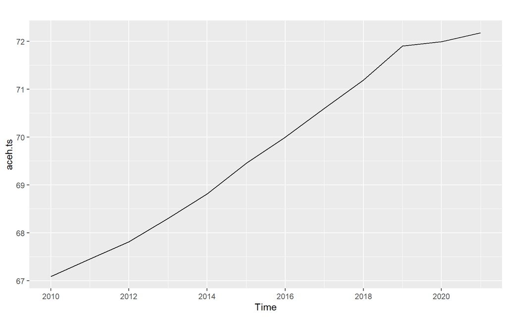

```r
autoplot(aceh.ts)
```

Berdasarkan plot, dapat diketahui bahwa IPM aceh dari tahun ke tahun mengalami peningkatan.

```r
cor(data_aceh$Tahun, data_aceh$Nilai)
```

```
## [1] 0.9944628
```

Berdasarkan plot dan korelasi, dapat dipastikan bahwa peubah Tahun dengan nilai IPM memiliki hubungan yang positif dengan nilai korelasi sebesar 0.9944628. Selanjutnya, model regresi dapat dibuat.

# Regresi

```r
model<- lm(Nilai~Tahun, data = data_aceh)
summary(model)
```

```
##
## Call:
## lm(formula = Nilai ~ Tahun, data = data_aceh)
##
## Residuals:
##      Min       1Q   Median       3Q      Max
## -0.35564 -0.14094 -0.00592  0.11916  0.38429
##
## Coefficients:
##               Estimate Std. Error t value Pr(>|t|)
## (Intercept) -958.10369   34.34725  -27.89 8.14e-11 ***
## Tahun          0.50997    0.01704   29.93 4.06e-11 ***
## ---
## Signif. codes:  0 '***' 0.001 '**' 0.01 '*' 0.05 '.' 0.1 ' ' 1
##
## Residual standard error: 0.2038 on 10 degrees of freedom
## Multiple R-squared:  0.989,  Adjusted R-squared:  0.9879
## F-statistic: 895.5 on 1 and 10 DF,  p-value: 4.061e-11
```

Model yang dihasilkan adalah
$$y_i = -958.10369 + 0.50997x_t$$
Berdasarkan ringkasan model dapat diketahui p-value dari uji-F < 0.05. Artinya, minimal terdapat satu variabel yang berpengaruh nyata terhadap model. Hasil uji-t parsial kedua parameter regresi, yaitu intersep dan koefisien regresi juga menunjukkan hal yang sama, yaitu memiliki p-value < α (5%) sehingga nyata dalam taraf 5%. Selanjutnya dapat dilihat juga nilai R2=0.989. Artinya, sebesar 98.9% keragaman nilai IPM dapat dijelaskan oleh peubah tahun. Hasil ini menunjukkan hasil yang bagus, seolah mendapatkan hasil terbaik. Namun, kita perlu melakukan uji terhadap sisaannya seperti berikut ini.

## Uji Asumsi

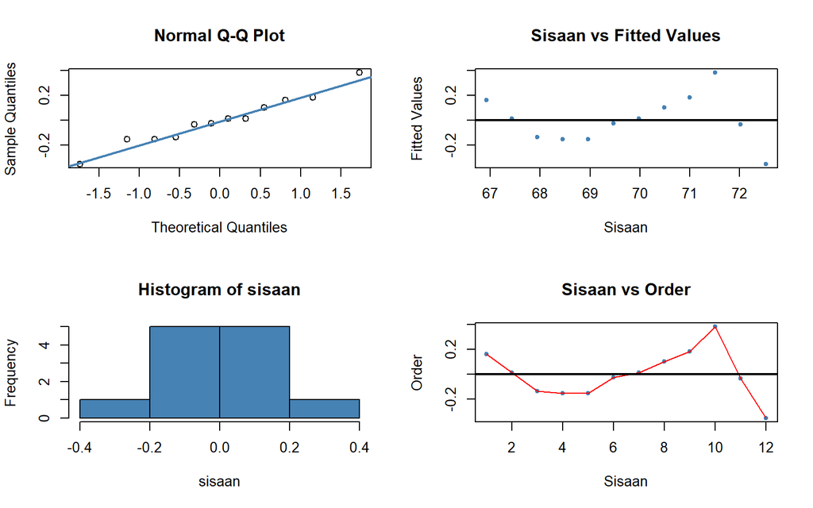

```r
#sisaan dan fitted value
sisaan<- residuals(model)
fitValue<- predict(model)

#Diagnostik dengan eksploratif
par(mfrow = c(2,2))
qqnorm(sisaan)
qqline(sisaan, col = "steelblue", lwd = 2)
plot(fitValue, sisaan, col = "steelblue", pch = 20, xlab = "Sisaan", ylab = "Fitted Values", main = "Sisaan vs Fitted Values")
abline(a = 0, b = 0, lwd = 2)
hist(sisaan, col = "steelblue")
plot(seq(1,12,1), sisaan, col = "steelblue", pch = 20, xlab = "Sisaan", ylab = "Order", main = "Sisaan vs Order")
lines(seq(1,12,1), sisaan, col = "red")
abline(a = 0, b = 0, lwd = 2)
```

Berdasarkan plot, dapat diketahui bahwa data ini sisaannya cenderung menyebar normal. Berdasarkan plot Sisaan vs Order, terdapat indikasi adanya autokorelasi pada sisaan. Oleh karena itu diperlukan uji formal untuk memastikan hal ini.

# Uji Autokorelasi

## Box test

```r
Box.test(aceh.ts, lag = 2, type = "Ljung-Box")
```

```
##
##  Box-Ljung test
##
## data:  aceh.ts
## X-squared = 14.752, df = 2, p-value = 0.000626
```

```r
Box.test(aceh.ts, lag = 3, type = "Ljung-Box")
```

```
##
##  Box-Ljung test
##
## data:  aceh.ts
## X-squared = 16.333, df = 3, p-value = 0.0009688
```

```r
Box.test(aceh.ts, lag = 4, type = "Ljung-Box")
```

```
##
##  Box-Ljung test
##
## data:  aceh.ts
## X-squared = 16.399, df = 4, p-value = 0.002528
```

## Plot sisaan

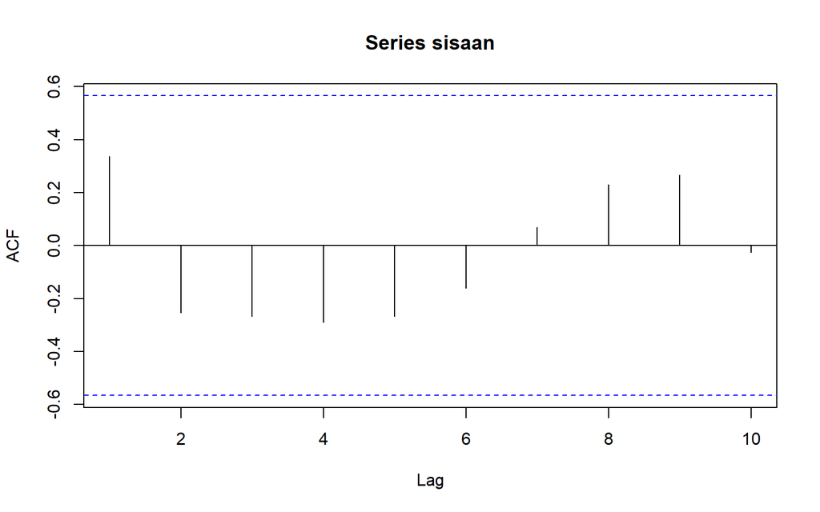

```r
acf(sisaan)
```

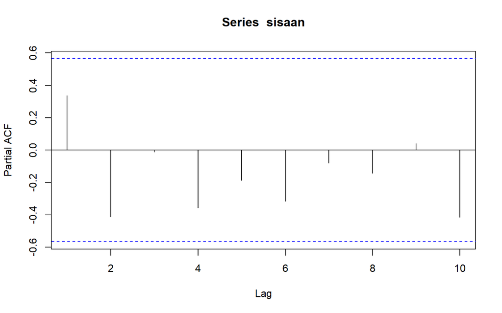

```r
pacf(sisaan)
```

Berdasarkan plot ACF dan PACF, terlihat semua masih berada dalam rentang batas dan tidak ada lag yang signifikan. Akan tetapi, untuk lebih memastikan perlu dilakukan uji formal.

## DW-Test

```r
#Deteksi autokorelasi dengan uji-Durbin Watson
#H0: tidak ada autokorelasi
#H1: ada autokorelasi
dwtest(model)
```

```
##
##  Durbin-Watson test
##
## data:  model
## DW = 0.95635, p-value = 0.006471
## alternative hypothesis: true autocorrelation is greater than 0
```

Berdasarkan uji formal, didapatkan nilai DW sebesar 0.95635 dan p-value sebesar 0.00, maka Tolak H0. Artinya terdapat cukup bukti untuk mengatakan bahwa terdapat autokorelasi sisaan. Penanganan yang akan digunakan menggunakan dua metode, yaitu Cochrane-Orcutt dan Hildret-Lu.

# Penanganan

## Cochrane-Orcutt

### Fungsi

```r
library(orcutt)
modelCO<-cochrane.orcutt(model)
modelCO
```

```
## Cochrane-orcutt estimation for first order autocorrelation
##
## Call:
## lm(formula = Nilai ~ Tahun, data = data_aceh)
##
##  number of interaction: 18
##  rho 0.535106
##
## Durbin-Watson statistic
## (original):    0.95635 , p-value: 6.471e-03
## (transformed): 1.10751 , p-value: 1.797e-02
##
##  coefficients:
## (Intercept)       Tahun
## -951.941111    0.506876
```

Model yang dihasilkan adalah
$$y_i=-951.941111 + 0.506876x_t$$

### Transformasi Manual

```r
rho<- modelCO$rho
rho
```

```
## [1] 0.5351064
```

```r
y <- data_aceh$Nilai
x <- data_aceh$Tahun
y.transformed <- y[-1] - rho * y[-length(y)]
x.transformed <- x[-1] - rho * x[-length(x)]
model.t <- lm(y.transformed ~ x.transformed)

summary(model.t)
```

```
##
## Call:
## lm(formula = y.transformed ~ x.transformed)
##
## Residuals:
##      Min       1Q   Median       3Q      Max
## -0.29716 -0.08613 -0.04312  0.10930  0.32221
##
## Coefficients:
##                 Estimate Std. Error t value Pr(>|t|)
## (Intercept)   -442.55132   35.67195  -12.41 5.80e-07 ***
## x.transformed    0.50688    0.03804   13.32 3.14e-07 ***
## ---
## Signif. codes:  0 '***' 0.001 '**' 0.01 '*' 0.05 '.' 0.1 ' ' 1
##
## Residual standard error: 0.1855 on 9 degrees of freedom
## Multiple R-squared:  0.9518, Adjusted R-squared:  0.9464
## F-statistic: 177.6 on 1 and 9 DF,  p-value: 3.14e-07
```

```r
dwtest(model.t)
```

```
##
##  Durbin-Watson test
##
## data:  model.t
## DW = 1.1075, p-value = 0.01797
## alternative hypothesis: true autocorrelation is greater than 0
```

```r
dwtest(modelCO)
```

```
##
##  Durbin-Watson test
##
## data:  modelCO
## DW = 1.1075, p-value = 0.01797
## alternative hypothesis: true autocorrelation is greater than 0
```

Setelah dilakukan penanganan dengan menggunakan Cochrane-Orcutt, ternyata masih terdapat autokorelasi. Hal ini dapat dipastikan dari nilai p-value setelah dilakukan penanganan sebesar 0.01797.